# Pamguard_tips_tricks

# Click Detector Window

A way to view “clicks” as they scroll.

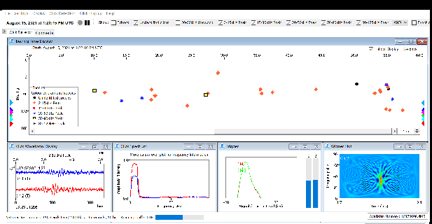

## Click Detector Tab

### Bearing Time Display

Not many tips. Here is what I can come up with:

1. This screen shows all clicks/blips/creaks/plops that trigger the settings. So, you still need to search for the clicks of interest.
2. You get one minute before you lose your clicks. If you get a busy screen and are nervous you are going to miss something, freeze the display by ticking the box in the upper right hand corner. Or make the time span bigger, for example to 2 minutes, until you catch up.
3. You need to get the start time and date, location and initial angle into the detector tab very quickly after thinking you have an encounter. I find it easiest to find the bearing and keep repeating it to myself in my head. Then, I go over to logger form, and hit F1 for start time/date and then F1 for location and then type in the number I’ve been repeating in my head into the bearing box. If you forget it, you can use the small triangles of color that match your click train just outside the y-axis to provide a pretty good guideline of bearing. Placing your cursor along a similar line horizontally in the click detector window will show you the bearing reading at the top of the scrolling click detector. Sometimes I’m trigger happy and start an encounter that is indeed nothing of interest and then I just clear the form and leave it available for an actual encounter. In order of priority:
   1. Start time/date (place cursor in the box on the logger form and press F1)
   2. Location lat/long (place cursor in the box on the logger form and press F1)
   3. Bearing (must type it in)

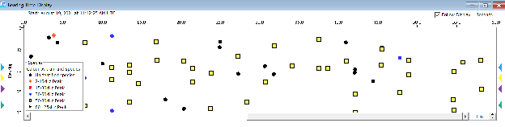

This example is showing a bunch of scatter from nearby ships. And we are in “shallow” water (120m), but entering Oceanographer Canyon (about 1000m), so along a sloping shelf, providing more scatter. Also, an echosounder is on (FE800 – at 50kHz). But it gets more “scatter” than this at times!

### Click Waveform Display

We don’t use this much, except to make sure that both hydrophones are reading in ok. Both of these lines “dance” as the click detector picks up new clicks of interest and plots them on this graph. There are slight variations in how each hydrophone receives a sound, based on their slight difference in locations along the hydrophone. On the towed array, Echidna, the hydrophones can be a max of 2m apart if you use the one closest to the ship and the one furthest from the skip, skipping the middle hydrophone. But, we tend to use the last two hydrophones, which are a meter apart , so they get the signals at different times and in slightly different ways.

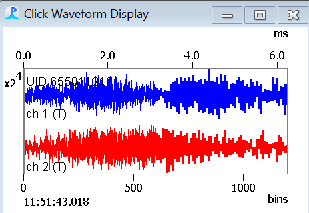

This is showing quite a bit of noise from a passing pleasure craft, moving at 30knots, 2nmi from our ship.

Just for fun, here is this ship, in the bearing time display:

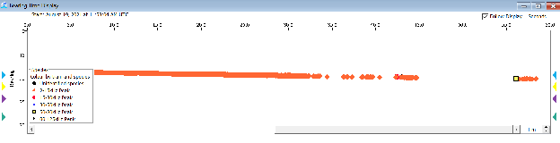

### Click Spectrum Display

This is mostly used to show the peak frequency of a particular click as received from hydrophone 1 and hydrophone 2. One is red, one is blue, just like the click waveform display above.

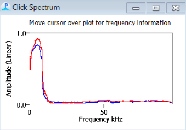

If you hover over the peak (or anywhere within the plot space), you will see a number show up above the plot that is the frequency of where the cursor is, and its amplitude. The peak frequency is the number that will be most useful to you. The peak frequency will help you categorize beaked whale clicks for example. Also, the shape of this click spectrum will help you categorize clicks into species. For example, a Cuvier’s click structure has a jagged leading edge to the peak frequency, whereas a True’s or Gervais’ click spectrum has a more smooth leading edge to its peak frequency.

### Trigger Display

We don’t use this too much. It is displaying some of the backend settings that determine whether or not to display a click in the bearing time display. Also the bars will dance, letting you know, the hydrophone is getting sound information from the surrounding waters.

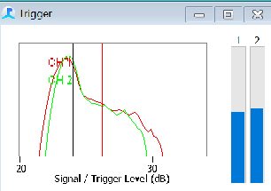

### Wigner Plot Display

This display is very useful in determining species categories. You need to left click on a click in the bearing time display in order for this plot to produce an image of that sound. The click below on the left is some ship noise from a passing fishing vessel. The click on the right is the ship’s echosounder (FE800) at 50kHz. The x-axis will change as the Wigner plot centers on the click, but the y-axis will remain constant, in this case displaying up to 96kHz.

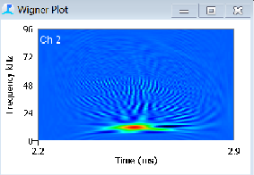

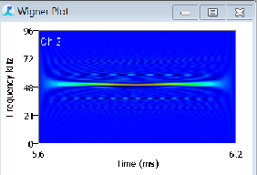

## Comments Tab

This is a nice place to put your “story for the day.” If you need to step away for the bathroom, or the ship is turning, or we decide to tow through lunch and not take the array out. This keeps a sequential and time stamped log of field notes that might be useful in post-processing.

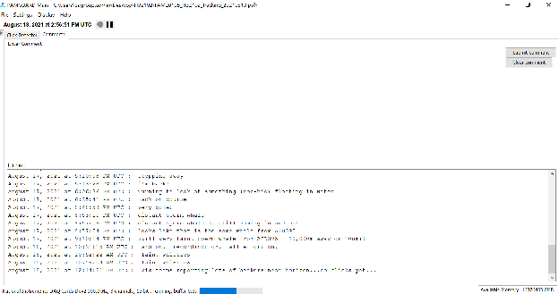

# Logger Forms Window

These are data input panels. Time, Lat/Long, Encounter #, localization info, species ID, and other notes can be inputted here. Often, this window is put next to the map window, vertically.

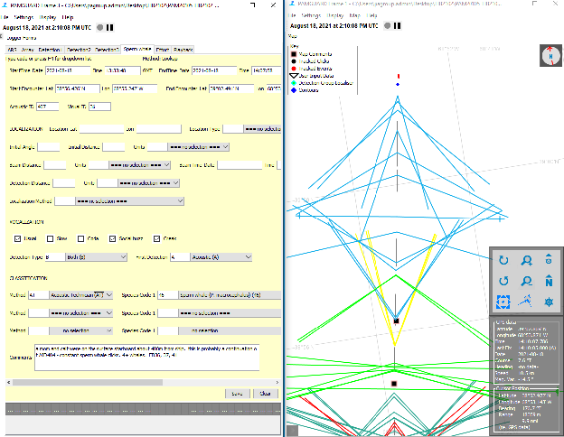

## ARS Tab

We haven’t been using this.

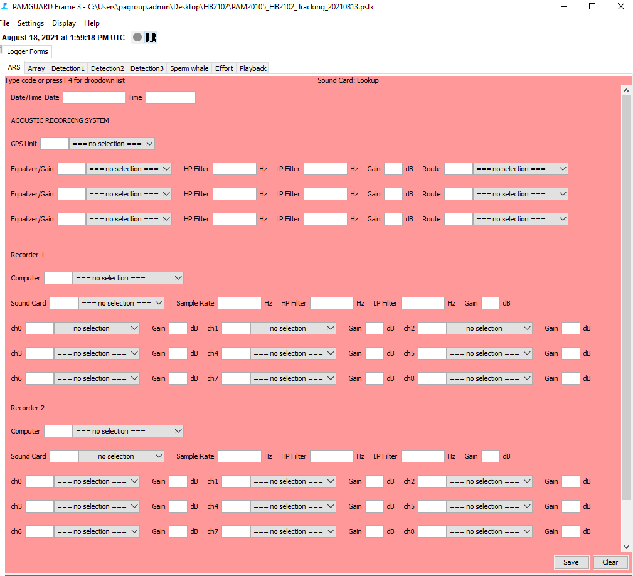

## Array Tab

We haven’t been using this.

[figure not shown]

## Detection1 Tab

The first detection you think you might log goes here. It could be:

- Something you see, but don’t hear (like a beaked whale click sequence)
- Something you hear, but don’t see (like a distant sperm whale train that isn’t picked up yet in the click detector or spectrogram display, or a faint whistle series you can hear and maybe even see in the spectrogram window, but the whistle detector isn’t highlighting it yet since it’s not strong enough)
- A clear click sequence
- A clear whistle sequence

It’d be up to the project manager, which things you put in, but it’s a bit of a judgement call most of the time. I like to put the next Acoustic Encounter number in here, so I can keep track of things easier.

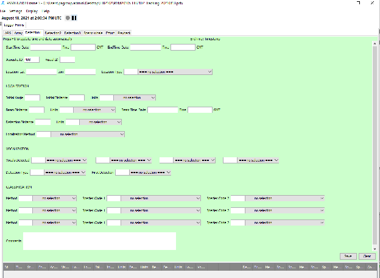

## Detection2 Tab

If another detection comes at the same time, you can use this second tab to have two going at once.

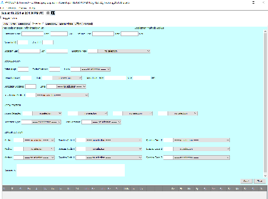

## Detection3 Tab

If a third detection comes in at the same time as the others, you can use this tab to track three acoustic encounters at the same time.

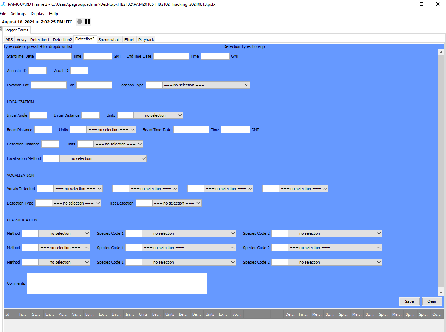

## Sperm Whale Tab

Sperm whales have their own tab. You can start a sperm whale detection in this tab and have it open while you are detecting other things.

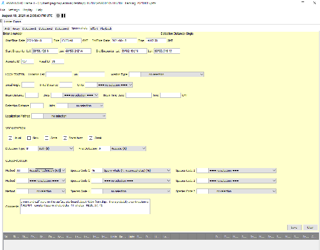

## Effort Tab

Whenever a new acoustician starts their shift, the echosounders go on or off, visuals go on or off, a new trackline begins, or anything other “effort related” activities happen, they can be logged here. Environmental conditions are sometimes collected in other ways (by visuals, for example), but if there is no visual effort, you can input the environmental conditions here, probably twice a day: morning and afternoon. You will likely need to manually input the names of your acousticians, cruise number, etc. into the logger form, so that it is an option on the drop down menus.

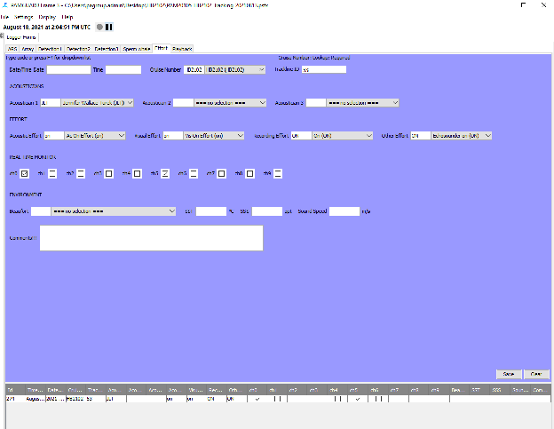

## Playback Tab

You can create your own tabs, too. In this case, this tab was created for a beaked whale tracking during times with and without a certain echosounder on.

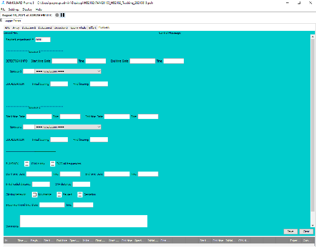

# Map Window

## Map Tab

1. Window is best viewed either at full screen, or more likely at half a screen, but vertical/portrait, rather than landscape. A landscape map view will likely not show you the distances you are measuring, which appear directly above the map key in the bottom right hand corner. They are cut off when the map window shrinks vertically too much.
2. Double click on the trackline where you first detected an acoustic encounter. This opens a “map comment” pop up which you can then put text into. The tracklines and localization lines do not save in the map file. But the dots left behind as map comments do save and are connected with the GPS coordinates. I like to type in “start loc AIDXXX” where XXX is the number of your encounter or acoustic ID. For example, start loc AID37 or start loc AID568. Some use just the letter “A” for acoustic: A37 or A568. I like writing out AID since there is also a UID number that is associated with whistles.
3. Similarly, double clicking on the best localization is nice, so that that information is easily pulled up later in the lab via map comments dropped along the way.
   - For sperm whales, I rarely drop localization map comments, since this is more easily done in the lab after the cruise.
   - For locations that are obviously one side of the boat or the other because no lines are converging on one side, and they all converge nicely on the other, I will type: animal loc AIDXXX.
   - If visuals have seen these animals in that location, too, I will type “animal loc AIDXXX (visuals too)
   - If I can’t determine if it is on the left or right of the ship’s trackline, but I have decent convergence of lines, giving me a nice left location and a nice right location, I will leave two comments, one in each spot. I label these with the word “possible” as I don’t know if it’s on the right or the left. “possible animal loc (L) AIDXXX” or “possible animal loc (R) AIDXXX”

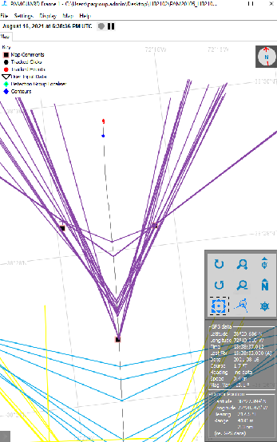

4. Some colors that randomly are produced for localizations are hard to see on certain backgrounds. For example: yellow! If it bothers you, you can change the background. Display 🡪 color scheme Day, Night and Print are shown below. I tend to just power through the bad colors since no background seems to accept all colors nicely.

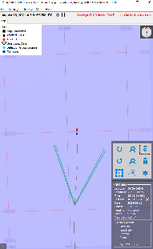

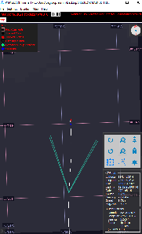

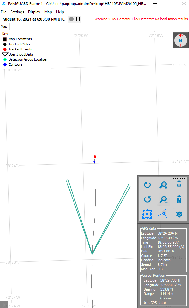

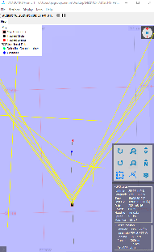

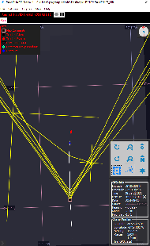

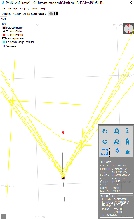

5. Scrolling with the wheel on the mouse is easier than the zoom in and out buttons, I think.
6. Clicking the measuring tool, lets you measure from one point to the next. It’s a little bit touchy, though. If you click on a pixel that already has information (a map comment, the ship track or a localization line), the starting point of the measurement won’t fix. You need to go just outside these other bits of information and drop your starting point in a clean spot on the map.

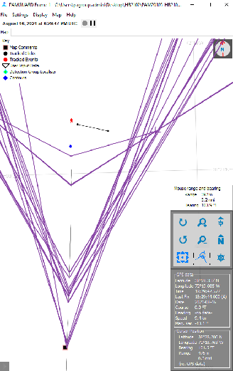

# Spectrogram Window

## Whistle Detector Tab

This tab scrolls the live spectrogram and associated bearing panel. The right side of the screen is the newest sound info. The left side of the screen is the oldest sound info. You can set the screen to show any span of time. One minute is the most appropriate window size. It’s nice to have this window length match up with the click detector time length such that they are both scrolling at the same rate and it’s easier to match up localized clicks/whistles on their bearing and relative position in the time span displayed. But at times, you may want to shorten or lengthen the amount of time displayed.

The top black bar is bearing versusverses time. It shows the bearing in degrees relative to the ship. 90 degrees is at the ship line. It could be right or left (we have left and right ambiguity due to having only the two hydrophones slightly offset from each other, but on the same line). We’d need a slight change in course (5-1020 degrees one way or the other) to determine which side the animal is on. 0 degrees is dead ahead. 180 degrees is dead behind. These are also to one side or the other. Depth is something to figure out in the lab.

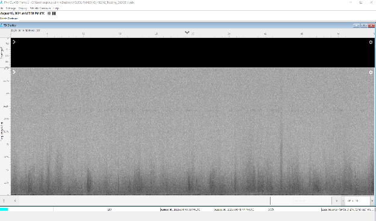

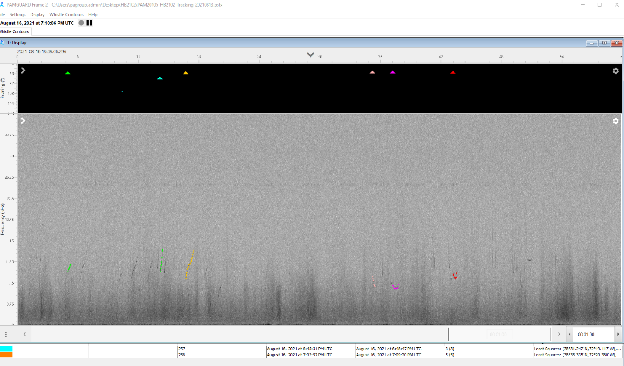

Not many “tricks” for this window. Here are a few:

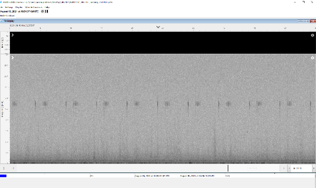

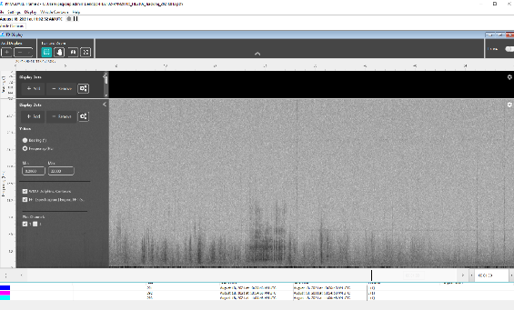